# Quantified Self Movement - Quality of Exercise

Sean Clarke

14 September 2015

# Introduction

## Assignment details

Using devices such as Jawbone Up, Nike FuelBand, and Fitbit it is now possible to collect a large amount of data about personal activity relatively inexpensively. These type of devices are part of the quantified self movement – a group of enthusiasts who take measurements about themselves regularly to improve their health, to find patterns in their behavior, or because they are tech geeks. One thing that people regularly do is quantify how much of a particular activity they do, but they rarely quantify how well they do it. In this project, your goal will be to use data from accelerometers on the belt, forearm, arm, and dumbell of 6 participants. They were asked to perform barbell lifts correctly and incorrectly in 5 different ways. More information is available from the website here: http://groupware.les.inf.puc-rio.br/har (see the section on the Weight Lifting Exercise Dataset).

## Further details

[This publication](http://groupware.les.inf.puc-rio.br/work.jsf?p1=10335) is the main reference from the group that produced the data.

The dataset was generated by instrumenting test subjects with accelerometers and then having them perform bicep curls according to the specification referred to by the “classe” variable in the data. These map as follows:

- **A** exactly according to the specification
- **B** throwing the elbows to the front
- **C** Lifting the dumbbell only halfway
- **D** lowering the dumbbell only halfway
- **E** throwing the hips to the front .

# Data Acquisition

The data using in this report, will be automatically downloaded from the following URLs

[Training Data](https://d396qusza40orc.cloudfront.net/predmachlearn/pml-training.csv)

[Test Data](https://d396qusza40orc.cloudfront.net/predmachlearn/pml-testing.csv)

A full discussion of the data cabe be found on the [Groupware@LES Website](http://groupware.les.inf.puc-rio.br/har)

# Exploratory Analysis

We begin by exploring the data in order to get a feel for it - as the datasets are so large, the output from the Analysis is not included in this report, but the code is in the Github repository to allow full reproduceability.

```r
dim(pmltraining)
str(pmltraining)
head(pmltraining,5)
```

# Data preparation

When we read in the data, we tidy up some of the mess including “DIV/0!” and null cells by using the na.strings argument to read.csv. After doing this, we remove the first 7 columns as they contain extraneous tracking information and we also remove the columns that contain nothing but NAs so we remove those and we convert classes to factors

```r
pmltraining <- pmltraining[-(1:7)]
pmltraining <- pmltraining[, colSums(is.na(pmltraining)) != nrow(pmltraining)]
pmltraining$classe <- factor(pmltraining$classe)
```

If we look at the variables in the dataset, we see that some summarised data is included (maximum/minimum/mean.standard deviation/variance) - we proceed to remove these variables from the dataset.

```r
columnsToRemove <- grep("^var.*|^stddev.*|^max.*|^min.*|^avg.*|^total.*|.*timestamp.*|user_name",names(pmltraining))
pmltraining <- pmltraining[-columnsToRemove]
```

Next we remove any predictors with near-zero variance.

```r
last <- ncol(pmltraining)
nzv <- nearZeroVar(pmltraining[,-last], saveMetrics=FALSE)
pmltraining <- pmltraining[,-nzv]
```

We notice that we have a considerable number of missing values still.

```r
nrow(pmltraining)
```

```
## [1] 19622
```

```r
colSums(is.na(pmltraining))
```

```
##                roll_belt               pitch_belt                 yaw_belt
##                        0                        0                        0
##       kurtosis_roll_belt      kurtosis_picth_belt       skewness_roll_belt
##                    19226                    19248                    19225
##     skewness_roll_belt.1      amplitude_roll_belt     amplitude_pitch_belt
##                    19248                    19216                    19216
##             gyros_belt_x             gyros_belt_y             gyros_belt_z
##                        0                        0                        0
##             accel_belt_x             accel_belt_y             accel_belt_z
##                        0                        0                        0
##            magnet_belt_x            magnet_belt_y            magnet_belt_z
##                        0                        0                        0
##                 roll_arm                pitch_arm                  yaw_arm
##                        0                        0                        0
##              gyros_arm_x              gyros_arm_y              gyros_arm_z
##                        0                        0                        0
##              accel_arm_x              accel_arm_y              accel_arm_z
##                        0                        0                        0
##             magnet_arm_x             magnet_arm_y             magnet_arm_z
##                        0                        0                        0
##        kurtosis_roll_arm       kurtosis_picth_arm         kurtosis_yaw_arm
##                    19294                    19296                    19227
##        skewness_roll_arm       skewness_pitch_arm         skewness_yaw_arm
##                    19293                    19296                    19227
##        amplitude_yaw_arm            roll_dumbbell           pitch_dumbbell
##                    19216                        0                        0
##             yaw_dumbbell   kurtosis_roll_dumbbell  kurtosis_picth_dumbbell
##                        0                    19221                    19218
##   skewness_roll_dumbbell  skewness_pitch_dumbbell  amplitude_roll_dumbbell
##                    19220                    19217                    19216
## amplitude_pitch_dumbbell         gyros_dumbbell_x         gyros_dumbbell_y
##                    19216                        0                        0
##         gyros_dumbbell_z         accel_dumbbell_x         accel_dumbbell_y
##                        0                        0                        0
##         accel_dumbbell_z        magnet_dumbbell_x        magnet_dumbbell_y
##                        0                        0                        0
##        magnet_dumbbell_z             roll_forearm            pitch_forearm
##                        0                        0                        0
##              yaw_forearm    kurtosis_roll_forearm   kurtosis_picth_forearm
##                        0                    19300                    19301
##    skewness_roll_forearm   skewness_pitch_forearm  amplitude_pitch_forearm
##                    19299                    19301                    19216
##          gyros_forearm_x          gyros_forearm_y          gyros_forearm_z
##                        0                        0                        0
##          accel_forearm_x          accel_forearm_y          accel_forearm_z
##                        0                        0                        0
##         magnet_forearm_x         magnet_forearm_y         magnet_forearm_z
##                        0                        0                        0
##                   classe
##                        0
```

We remove colums with more than 90% missing values

```r
pmltraining <- pmltraining[, colSums(is.na(pmltraining))/nrow(pmltraining) <= .9]
colSums(is.na(pmltraining))
```

```
##         roll_belt        pitch_belt          yaw_belt      gyros_belt_x
##                 0                 0                 0                 0
##      gyros_belt_y      gyros_belt_z      accel_belt_x      accel_belt_y
##                 0                 0                 0                 0
##      accel_belt_z     magnet_belt_x     magnet_belt_y     magnet_belt_z
##                 0                 0                 0                 0
##          roll_arm         pitch_arm           yaw_arm       gyros_arm_x
##                 0                 0                 0                 0
##       gyros_arm_y       gyros_arm_z       accel_arm_x       accel_arm_y
##                 0                 0                 0                 0
##       accel_arm_z      magnet_arm_x      magnet_arm_y      magnet_arm_z
##                 0                 0                 0                 0
##     roll_dumbbell    pitch_dumbbell      yaw_dumbbell  gyros_dumbbell_x
##                 0                 0                 0                 0
##  gyros_dumbbell_y  gyros_dumbbell_z  accel_dumbbell_x  accel_dumbbell_y
##                 0                 0                 0                 0
##  accel_dumbbell_z magnet_dumbbell_x magnet_dumbbell_y magnet_dumbbell_z
##                 0                 0                 0                 0
##      roll_forearm     pitch_forearm       yaw_forearm   gyros_forearm_x
##                 0                 0                 0                 0
##   gyros_forearm_y   gyros_forearm_z   accel_forearm_x   accel_forearm_y
##                 0                 0                 0                 0
##   accel_forearm_z  magnet_forearm_x  magnet_forearm_y  magnet_forearm_z
##                 0                 0                 0                 0
##            classe
##                 0
```

This leaves us with no missing values which is pleasing as all the elimination of predictors that we have done has been based on pretty stringent requirements - we havent easily thrown data away. This also means that we dont need to do any imputation.

# Model Building

We set out to determine whether to use Recursive Partitioning or the Random Forest algorithm to build our model. We also want to gain a feel for how effective the algorithm is and to attempt to avoid over-fitting. In order to achieve these aims, we will carry out cross-validation using k-fold validation.

In order to do this, we create folds in the data which we then loop through. During each iteration we build a training set from everything contained in the fold and testing set from all the data that isnt included in the fold. We build a model using the training set and predict the test set and store the predictions and true values for classe on each iteration. We can use the resulting data set to estimate and visualise errors.

## Random Forest

```r
 observed <- c()
 predicted <- c()
 folds <- createFolds(y=pmltraining$classe, k=10, list = TRUE, returnTrain = TRUE)
 for (i in 1:10){
   foldtrain <- pmltraining[folds[[i]],]
   foldtest <- pmltraining[-folds[[i]],]
   last <- ncol(foldtest)
   foldfit <- randomForest(classe ~ ., data=foldtrain, method="class")
   observed <- c(observed, foldtest$classe)
   predicted <- c(predicted, predict(foldfit, foldtest[-last]))
 }
resultsRF <- as.data.frame(cbind(observed,predicted))
names(resultsRF) <- c("observed", "predicted")
resultsRF$Difference <- abs(resultsRF$observed - resultsRF$predicted)
summary(resultsRF$Difference)
```

```
##     Min.  1st Qu.   Median     Mean  3rd Qu.     Max.
## 0.000000 0.000000 0.000000 0.003313 0.000000 4.000000
```

```r
sqrt(mean((resultsRF$observed - resultsRF$predicted)^2))
```

```
## [1] 0.06264317
```

```r
nrow(subset(resultsRF, resultsRF$observed==resultsRF$predicted))*100/nrow(resultsRF)
```

```
## [1] 99.68403
```

We evaluate the Root Mean Square error between the predicted values and corresponding actual values in consolidated data that we return from the k-fold validation. We use the root mean square(RMS) error to deal with the fact that we get both positive and negative differences. We see that the RMS error is small which suggests that our Random Forest based model is doing a good job of predicting values. We also plot predicted versus observed values of classe from the data recorded during the cross-validation in Figure 1. We see that for the Random Forest algorithm a large proportion(99.7%) of the predicted values lie on the perfect prediction line shown in red in the figure.

```r
 observed <- c()
 predicted <- c()
 folds <- createFolds(y=pmltraining$classe, k=10, list = TRUE, returnTrain = TRUE)
 for (i in 1:10){
   foldtrain <- pmltraining[folds[[i]],]
   foldtest <- pmltraining[-folds[[i]],]
   last <- ncol(foldtest)
   foldfit <- rpart(classe ~ ., data=foldtrain, method="class")
   observed <- c(observed, foldtest$classe)
   predicted <- c(predicted, predict(foldfit, foldtest[-last], type="class"))
 }
resultsRP <- as.data.frame(cbind(observed,predicted))
names(resultsRP) <- c("observed", "predicted")
resultsRP$Difference <- abs(resultsRP$observed - resultsRP$predicted)
summary(resultsRP$Difference)
```

```
##    Min. 1st Qu.  Median    Mean 3rd Qu.    Max.
##  0.0000  0.0000  0.0000  0.4268  0.7500  4.0000
```

```r
sqrt(mean((resultsRP$observed - resultsRP$predicted)^2))
```

```
## [1] 0.9633483
```

```r
nrow(subset(resultsRP, resultsRP$observed==resultsRP$predicted))*100/nrow(resultsRP)
```

```
## [1] 74.99745
```

The figure below shows the difference in the quality in fit between the two models - it should be noted that Jitter was added to the plots in order to illustrate the number of points - the points actually all fall on integer intersection points.

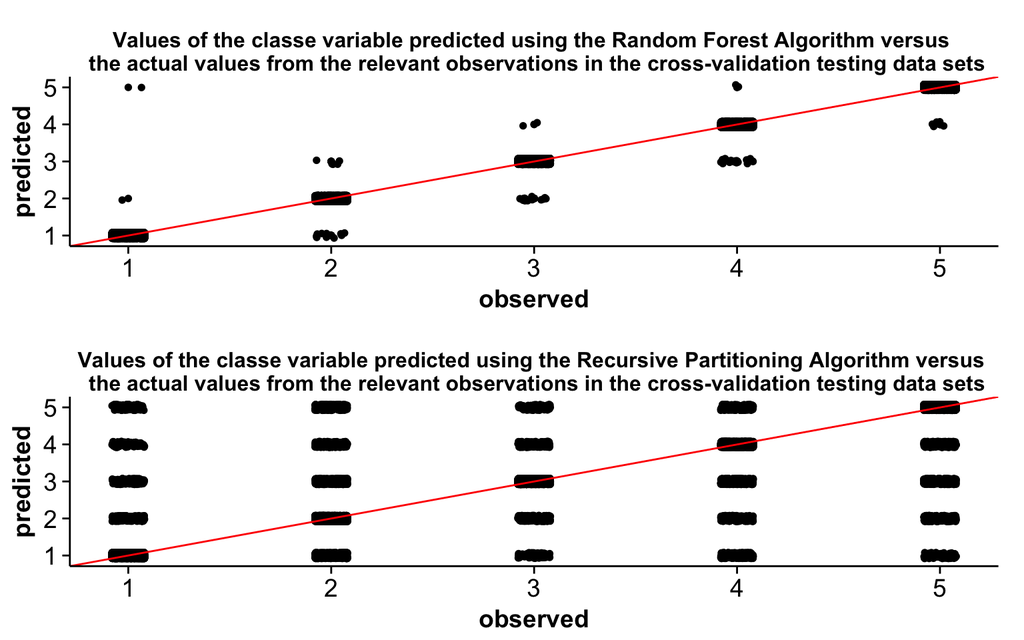

Based on the above analysis, we proceed using the Random Forest algorithm to build out final model.

# Model Building

We now proceed to build our model using the full training data set.

```r
model <- randomForest(classe ~ ., data=pmltraining, method="class")
```

We proceed to look at the effectiveness of predicting the values that we already know from the training set which will allow us to estimate the **In Sample Error**.

```r
last <- ncol(pmltraining)
insamppred <- predict(model, pmltraining[-last])
insamppred <- as.data.frame(cbind(insamppred, pmltraining$classe))
names(insamppred) <- c("Predicted", "Observed")
CFM <- confusionMatrix(insamppred$Predicted, insamppred$Observed)
CFM$table
```

```
##           Reference
## Prediction    1    2    3    4    5
##          1 5580    0    0    0    0
##          2    0 3797    0    0    0
##          3    0    0 3422    0    0
##          4    0    0    0 3216    0
##          5    0    0    0    0 3607
```

So as we can see from the Confusion Matrix, the model is extremely good at fitting the data in the training set, so much so that the In Sample Error is 0. This does lead to some concerns around potential over-fitting. Obviously the In Sample Error isnt much help in determing the **Out of Sample Error** as all we can say is that it is greater than zero!!!!

# Prediction

We now read in our test set and clean up as necessary in a consistent manner to what we did for the training data set.

```r
pmltest <- read.csv(FilePathTest, stringsAsFactors = FALSE, na.strings = c("", "NA", "#DIV/0!"))
pmltest <- pmltest[-(1:7)]
FinalPredictions <- predict(model, pmltest)
summary(FinalPredictions)
```

```
## A B C D E
## 7 8 1 1 3
```

# Conclusions

Out of the two models that we considered, the Random Forest algorithm is clearly the most effective at modelling the training set. Care will need to be taken when applying the model to the test dataset in cae this was down to overfitting.